# 1주차 패키지 문병철

Ch.1 -0번 패키지를 부르고, 문제 기본세팅을 해줍니다.

```r
library(dplyr)
library(tidyverse)
library(data.table)
setwd('C:/Users/user/Desktop/1주차패키지')

data <- fread('data.csv',data.table = FALSE)
```

Ch.1 -1번 str으로 데이터 구성을 보고, 각 열마다 NA개수와 unique값 개수를 확인해봅니다.

```
## 'data.frame':    5165 obs. of  8 variables:
##  $ patient_id    : 'integer64' num  4.94e-315 4.94e-315 4.94e-315 4.94e-315 4.94e-315 ...
##  $ sex           : chr  "male" "male" "male" "male" ...
##  $ age           : chr  "50s" "30s" "50s" "20s" ...
##  $ country       : chr  "Korea" "Korea" "Korea" "Korea" ...
##  $ province      : chr  "서울" "서울" "서울" "서울" ...
##  $ city          : chr  "강서구" "중랑구" "종로구" "마포구" ...
##  $ confirmed_date: IDate, format: "2020-01-23" "2020-01-30" ...
##  $ state         : chr  "released" "released" "released" "released" ...
```

```
##     patient_id            sex            age        country       province
##              0              0              0              0              0
##           city confirmed_date          state
##              0              3              0
```

```
## [1] 5164
```

```
## [1] 3
```

```
## [1] 12
```

```
## [1] 16
```

```
## [1] 17
```

```
## [1] 163
```

```
## [1] 149
```

```
## [1] 3
```

#Ch.1 2-1번 omit함수를 이용해 NA가 있는 행을 지웁니다.

```r
data <- na.omit(data)
```

```r
data <- data[-which(data$sex == "" | data$age =="" | data$city ==""),]
```

#Ch.1 3번 country가 ’Korea’인 행만 남기고, country 열을 제거합니다.

```r
data <- data %>% filter(country == "Korea") %>% select(-country)
```

[output not shown]

#Ch.1 6번

```r
data <- data%>% group_by(confirmed_date) %>% mutate(confirmed_number = n())
```

#Ch.1 7번

```r
data$wday = ifelse(weekdays(data$confirmed_date) == "토요일"|
                                        weekdays(data$confirmed_date) == "일요일","주말","주중")
```

#Ch.1 8번

```r
with(data %>% group_by(age,confirmed_date) %>% summarise(n = n()), tapply(n,age,summary))
```

```
## $`0s`
##    Min. 1st Qu.  Median    Mean 3rd Qu.    Max.
##   1.000   1.000   1.000   1.488   2.000   3.000
##
## $`100s`
##    Min. 1st Qu.  Median    Mean 3rd Qu.    Max.
##       1       1       1       1       1       1
##
## $`10s`
##    Min. 1st Qu.  Median    Mean 3rd Qu.    Max.
##   1.000   1.000   2.000   2.276   3.000   8.000
##
## $`20s`
##    Min. 1st Qu.  Median    Mean 3rd Qu.    Max.
##   1.000   1.000   3.500   7.526  11.000  43.000
##
## $`30s`
##    Min. 1st Qu.  Median    Mean 3rd Qu.    Max.
##   1.000   2.000   3.000   5.051   8.000  17.000
##
## $`40s`
##    Min. 1st Qu.  Median    Mean 3rd Qu.    Max.
##   1.000   1.000   2.000   4.931   6.000  33.000
##
## $`50s`
##    Min. 1st Qu.  Median    Mean 3rd Qu.    Max.
##   1.000   1.000   3.000   6.112   9.000  31.000
##
## $`60s`
##    Min. 1st Qu.  Median    Mean 3rd Qu.    Max.
##   1.000   1.000   3.000   4.722   7.000  22.000
##
## $`70s`
##    Min. 1st Qu.  Median    Mean 3rd Qu.    Max.
##   1.000   1.000   2.000   2.908   3.250  13.000
##
## $`80s`
##    Min. 1st Qu.  Median    Mean 3rd Qu.    Max.
##   1.000   1.000   2.000   3.019   3.750  24.000
##
## $`90s`
##    Min. 1st Qu.  Median    Mean 3rd Qu.    Max.
##   1.000   1.000   1.000   2.286   2.000  16.000
```

#Ch2. 1번

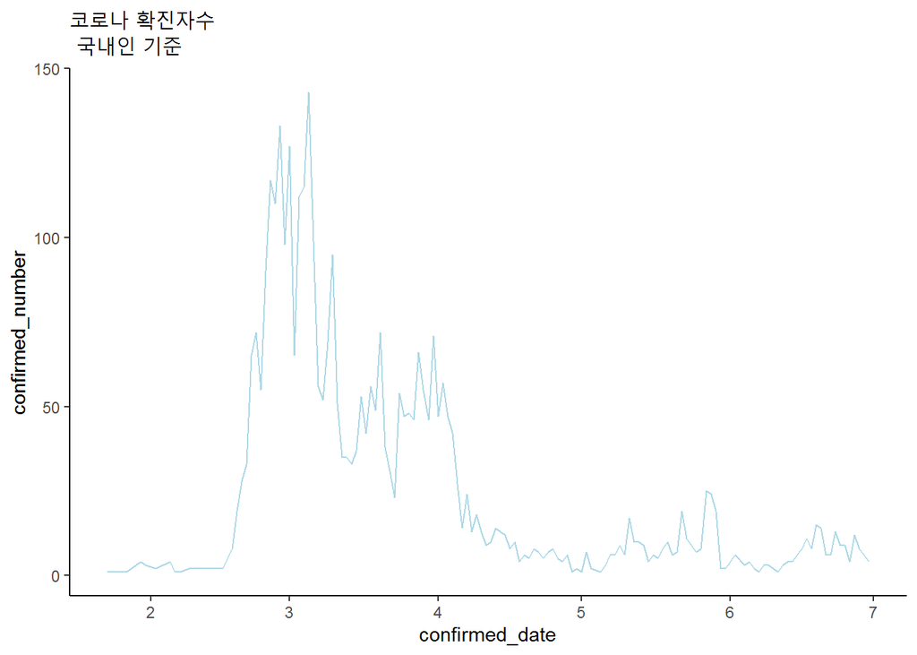

```r
data %>% ggplot(aes(x=confirmed_date,y=confirmed_number)) +
    geom_line(color = 'lightblue') + labs(title="코로나 확진자수 \n 국내인 기준") +
    theme(plot.title = element_text(hjust = 0.5 , face = "bold")) + theme_classic()
```

#Ch2. 1-2번

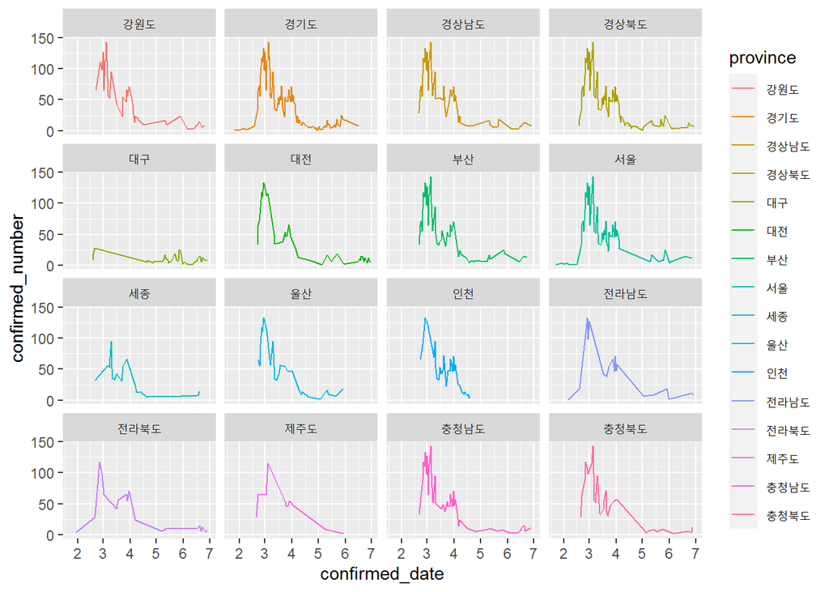

```r
ggplot(data = data, aes(x=confirmed_date, y=confirmed_number,
                            group = province, colour =  province))+
         geom_line()+
         facet_wrap(~province)
```

#Ch.2. 2번

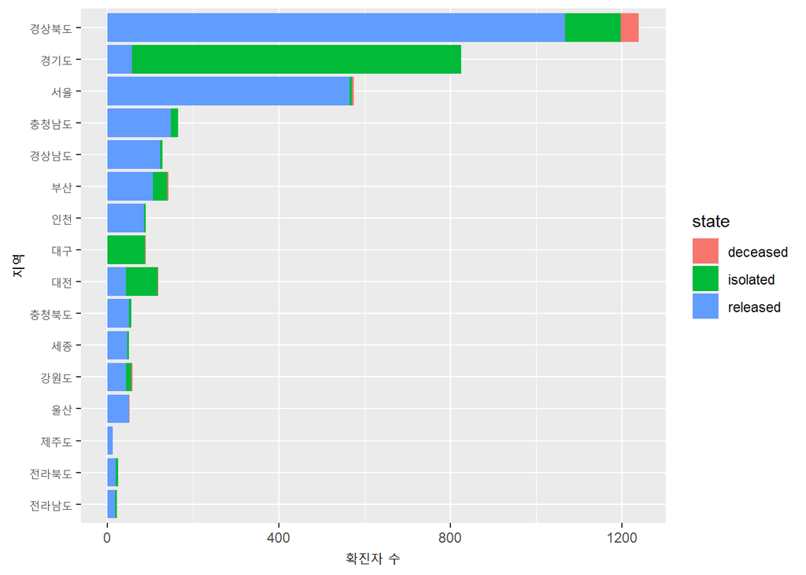

```r
graph <- data %>% group_by(province,state) %>% summarize(sum=n())
ggplot(graph, aes(x=reorder(province, sum),
                  y=sum,
                  fill=state))+
  geom_col()+coord_flip()+
  xlab("지역")+ylab("확진자 수")
```

#Ch.2. 3번

```r
data3 <- data %>% group_by(age,confirmed_date) %>% summarize(confirmed_number=n())
```

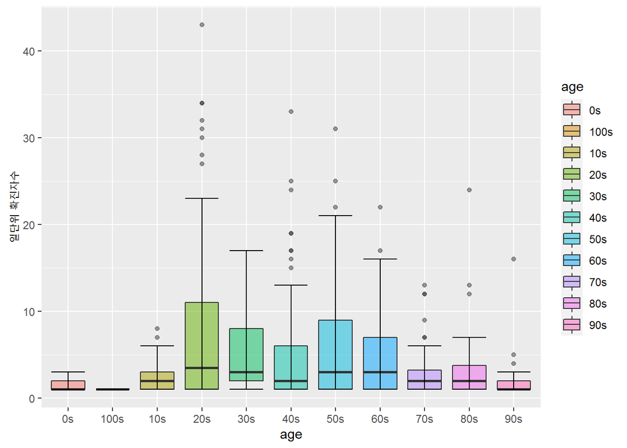

```r
ggplot(data3, aes(x=age, y=confirmed_number,fill=age, group=age))+
  geom_boxplot(oulier.shape=NA, alpha=0.5)+
  stat_boxplot(geom = 'errorbar')+
  labs(x='age', y='일단위 확진자수')
```

#Ch2. 3-2번

```r
result=aov(confirmed_number~age+confirmed_date,data=data3)
result
```

```
## Call:
##    aov(formula = confirmed_number ~ age + confirmed_date, data = data3)
##
## Terms:
##                       age confirmed_date Residuals
## Sum of Squares   2574.808       4730.759 18033.130
## Deg. of Freedom        10              1       779
##
## Residual standard error: 4.811349
## Estimated effects may be unbalanced
```

```r
summary(result)
```

```
##                 Df Sum Sq Mean Sq F value Pr(>F)
## age             10   2575     257   11.12 <2e-16 ***
## confirmed_date   1   4731    4731  204.36 <2e-16 ***
## Residuals      779  18033      23
## ---
## Signif. codes:  0 '***' 0.001 '**' 0.01 '*' 0.05 '.' 0.1 ' ' 1
```

[output not shown]

#Ch3. 3

```
set.seed(1234)
index <- sample(nrow(Boston), nrow(Boston)*0.70)
Boston.train <- Boston[index,]
Boston.test <- Boston[-index,]
```

```
model <- lm(medv ~., data=Boston.train)
model.sum <- summary(model)
model.sum
```

Ch3. 4번

```
value <- coef(summary(model))[,1] %>% round(2)
variables <- c('(intercept)',(Boston %>% names())[-which(names(Boston)=='medv')])

coef <- cbind(variables,value)
coef <- as.data.frame(coef)



p <- ggplot(data=coef,aes(x=reorder(variables,as.numeric(value) ),y=as.numeric(value)))+
  geom_bar(stat='identity',fill = 'yellow', alpha=0.4)+
  coord_flip()+
  geom_text(aes(label=value),  color="black", size=3.5)+
  labs(x='intercept and variables',y='value')+
  theme_classic()
```